# R markdown - intro and some basics

### 4. Tables:

`kable` in `knitr` works well for html, pdf, and word document outputs.

```r
knitr::kable(data, # data frame
             digits = 2, # round to 2 digits
             col.names = gsub("[.]", " ", names(data)),# format column names, substitute the dots with spaces
             align = "c", # alignment center
             longtable = TRUE) # formats tables that span multiple pages
```

| X | transect position | dist from transect | substrate type | snail size | snail weight | snail aggressiveness | snail color |
| --- | --- | --- | --- | --- | --- | --- | --- |
| 1 | 1.00 | 0.42 | C | 11.78 | 0.36 | 1 | yellow |
| 2 | 1.66 | -0.40 | A | 11.80 | 0.36 | 1 | yellow |
| 3 | 2.31 | -1.53 | A | 13.70 | 0.74 | 1 | yellow |
| 4 | 2.97 | 0.26 | B | 13.77 | 0.75 | 1 | pink |
| 5 | 3.62 | 0.11 | C | 13.08 | 0.62 | 1 | blue |
| 6 | 4.28 | -0.54 | A | 14.48 | 0.90 | 1 | yellow |
| 7 | 4.93 | 0.16 | C | 17.13 | 1.43 | 1 | pink |
| 8 | 5.59 | -0.40 | B | 14.91 | 0.98 | 1 | yellow |
| 9 | 6.24 | -0.21 | A | 18.02 | 1.60 | 2 | pink |
| 10 | 6.90 | -1.68 | C | 17.32 | 1.46 | 2 | blue |
| 11 | 7.55 | -1.76 | A | 21.88 | 2.38 | 2 | blue |
| 12 | 8.21 | -2.16 | A | 20.32 | 2.06 | 2 | yellow |
| 13 | 8.86 | 2.10 | B | 24.01 | 2.80 | 3 | blue |
| 14 | 9.52 | 0.00 | A | 23.59 | 2.72 | 3 | orange |
| 15 | 10.17 | 0.37 | B | 21.78 | 2.36 | 2 | pink |
| 16 | 10.83 | 0.54 | A | 20.01 | 2.00 | 2 | blue |
| 17 | 11.48 | -1.14 | C | 22.90 | 2.58 | 3 | yellow |
| 18 | 12.14 | -0.24 | C | 24.82 | 2.96 | 3 | yellow |
| 19 | 12.79 | -0.35 | C | 27.82 | 3.56 | 4 | yellow |
| 20 | 13.45 | -1.46 | A | 25.48 | 3.10 | 3 | yellow |
| 21 | 14.10 | -1.46 | C | 26.53 | 3.31 | 4 | pink |
| 22 | 14.76 | -1.24 | B | 31.53 | 4.31 | 5 | pink |
| 23 | 15.41 | 1.17 | C | 24.11 | 2.82 | 3 | orange |
| 24 | 16.07 | -0.49 | C | 26.22 | 3.24 | 3 | yellow |
| 25 | 16.72 | 0.90 | B | 29.90 | 3.98 | 4 | blue |
| 26 | 17.38 | 0.26 | A | 29.43 | 3.89 | 4 | yellow |
| 27 | 18.03 | -0.93 | A | 28.87 | 3.77 | 4 | pink |
| 28 | 18.69 | 1.08 | A | 30.81 | 4.16 | 5 | pink |
| 29 | 19.34 | 1.04 | B | 31.69 | 4.34 | 5 | blue |
| 30 | 20.00 | -0.96 | C | 30.05 | 4.01 | 5 | yellow |

### 5. Figures made using imbedded script:

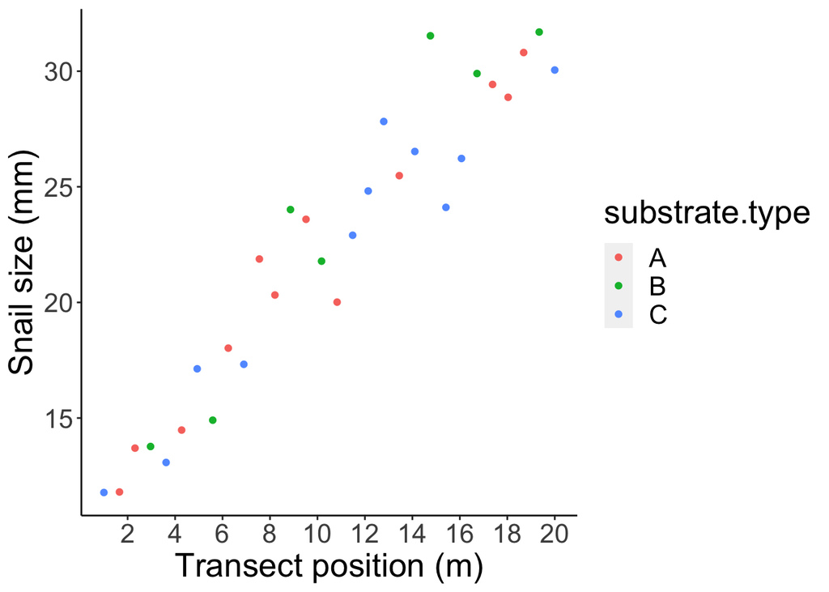

Figure 1. Snail body sizes along the transect position

```r
# plot code from week 1:
    ggplot(data = data, aes(x = transect.position, y = snail.size)) +
      geom_point(aes(col = substrate.type)) +
      theme(panel.background = element_blank(),
            axis.line = element_line(color = "black"),
            text = element_text(size = 20)) +
      scale_x_continuous(name = "Transect position (m)", breaks = seq(-10, 20, by =2)) +
      scale_y_continuous(name = "Snail size (mm)", breaks = seq(-10, 40, by = 5))
```

### Rendering and customization of the file

- pick a theme, or stick with a default
- render to PDF or html (some themes will not work to PDF)
- html (most common)
- table of contents
- execute the code in R markdown and show out put in R markdown is the default. To change that go to ‘settings’ (next to the knit) and select ‘chunk output in Console’

### Resources:

- [Rmarkdown cheatsheet, pdf](https://rmarkdown.rstudio.com/lesson-15.HTML)
- [Rmarkdown cheatsheet, web](https://rstudio.github.io/cheatsheets/html/rmarkdown.html)
- themes [R markdown book](https://rmarkdown.rstudio.com/lesson-1.html)